# QBIO 490 Week 8: TCGA-BRCA Methylation

Austin Lee

November 2, 2026

```r
library(data.table)
library(limma)
library(DESeq2)
library(ggplot2)

knitr::opts_chunk$set(echo = TRUE, fig.align = "center")
results_dir <- "results"
figures_dir <- "figures"
```

## 0.1 Purpose and data

This notebook asks whether metastatic and primary solid-tumor TCGA-BRCA samples differ in DNA methylation and whether hypermethylation coincides with lower transcription for a gene of interest. I ran the analysis on USC CARC using TCGA-BRCA Illumina HumanMethylation450 beta values and STAR-count RNA-seq data downloaded from the NCI Genomic Data Commons with `TCGAbiolinks`. Following the assignment instructions, the phenotype came from `colData(methylation450)$definition` and was restricted to `Primary solid Tumor` and `Metastatic`. The methylation comparison includes 793 primary and 5 metastatic samples; the matched RNA comparison includes 782 primary and 5 metastatic samples.

The raw GDC matrices are too large for GitHub, so this repository contains the CARC analysis and job scripts, full compressed statistical results, compact result tables, plot data, figures, and the rendered notebook. The completed run was Slurm job 13663807 on USC CARC Discovery.

```r
analysis_summary <- fread(file.path(results_dir, "analysis_summary.csv"))
knitr::kable(analysis_summary, col.names = c("Metric", "Value"))
```

| Metric | Value |
| --- | --- |
| Execution platform | USC CARC Discovery |
| CARC host | b05-04.hpc.usc.edu |
| Slurm job ID | 13663807 |
| Methylation primary samples | 793 |
| Methylation metastatic samples | 5 |
| Retained CpG probes | 178810 |
| Significant CpG probes | 225 |
| RNA primary samples | 782 |
| RNA metastatic samples | 5 |
| Genes after count filter | 53494 |
| Significant downregulated genes | 219 |
| Effect-size hypermethylated genes | 249 |
| Intersecting genes | 1 |
| Selected gene | CD164L2 |

## 0.2 Data preparation

The GDC data were prepared as `SummarizedExperiment` objects. I retained the two requested definitions, removed methylation probes with missing beta values or ambiguous gene annotations, and matched RNA and methylation specimens by the first 15 characters of the TCGA barcode after removing duplicate RNA aliquots. This left 178,810 CpG probes and 53,494 RNA genes after the required total-count filter.

```r
library(TCGAbiolinks)
library(SummarizedExperiment)

methyl_query <- GDCquery(
  project = "TCGA-BRCA",
  data.category = "DNA Methylation",
  data.type = "Methylation Beta Value",
  platform = "Illumina Human Methylation 450",
  data.format = "Dataframe"
)
GDCdownload(methyl_query, directory = "analysis_data/GDCdata")
methylation450 <- GDCprepare(methyl_query,
                             directory = "analysis_data/GDCdata")

methylation_clinical_all <- as.data.frame(colData(methylation450))
keep_methyl <- methylation_clinical_all$definition %in%
  c("Primary solid Tumor", "Metastatic")
methylation_clinical <- methylation_clinical_all[keep_methyl, , drop = FALSE]
methylation_clinical$definition <- factor(
  methylation_clinical$definition,
  levels = c("Primary solid Tumor", "Metastatic")
)

betas <- assay(methylation450)[, keep_methyl, drop = FALSE]
cpg_sites_all <- as.data.frame(rowData(methylation450))
gene_annotation <- as.character(cpg_sites_all$gene)
site_mask <- !is.na(gene_annotation) & gene_annotation != "" &
  !grepl("-", gene_annotation, fixed = TRUE) &
  !grepl(";", gene_annotation, fixed = TRUE) & complete.cases(betas)
betas <- betas[site_mask, , drop = FALSE]
gene_annotation <- gene_annotation[site_mask]

rna_query <- GDCquery(
  project = "TCGA-BRCA",
  data.category = "Transcriptome Profiling",
  data.type = "Gene Expression Quantification",
  workflow.type = "STAR - Counts"
)
GDCdownload(rna_query, directory = "analysis_data/GDCdata")
rna_se <- GDCprepare(rna_query, directory = "analysis_data/GDCdata")
rna_counts_all <- assay(rna_se, "unstranded")
rna_gene_names <- as.character(rowData(rna_se)$gene_name)

sample_key <- function(x) substr(x, 1, 15)
rna_keys <- sample_key(colnames(rna_counts_all))
unique_rna <- !duplicated(rna_keys)
rna_counts_all <- rna_counts_all[, unique_rna, drop = FALSE]
rna_keys <- rna_keys[unique_rna]
methyl_keys <- sample_key(rownames(methylation_clinical))
matched_methyl <- match(rna_keys, methyl_keys)
matched <- !is.na(matched_methyl)
rna_counts <- rna_counts_all[, matched, drop = FALSE]
matched_methyl <- matched_methyl[matched]
rna_clinical <- data.frame(
  definition = factor(methylation_clinical$definition[matched_methyl],
    levels = c("Primary solid Tumor", "Metastatic")),
  row.names = colnames(rna_counts)
)
```

# 1 1. Naive differential methylation

Beta values were clipped away from zero and one and transformed to M-values, which are better behaved for linear modeling. I fit a limma model for metastatic versus primary tumor at every retained probe. The volcano plot uses Benjamini-Yekutieli (BY) adjusted p-values and marks probes with adjusted p < 0.05 and an absolute M-value difference of at least 1.

```r
betas[betas < 1e-6] <- 1e-6
betas[betas > 1 - 1e-6] <- 1 - 1e-6
m_values <- log2(betas / (1 - betas))
metastatic <- methylation_clinical$definition == "Metastatic"

fit <- eBayes(lmFit(m_values, model.matrix(~ metastatic)))
methylation_results <- data.table(
  probe_id = rownames(m_values),
  gene_name = gene_annotation,
  m_value_difference = fit$coefficients[, "metastaticTRUE"],
  p_value = fit$p.value[, "metastaticTRUE"]
)
methylation_results[, adj_p_value := p.adjust(p_value, method = "BY")]
methylation_results[, significant :=
  adj_p_value < 0.05 & abs(m_value_difference) >= 1]
```

```r
methylation_file <- file.path(
  results_dir, "methylation_results_metastatic_vs_primary.csv.gz"
)
methylation_results <- fread(
  cmd = paste("gzip -dc", shQuote(methylation_file))
)
cat("Significant CpG probes:", sum(methylation_results$significant), "\n")
```

```
Significant CpG probes: 225
```

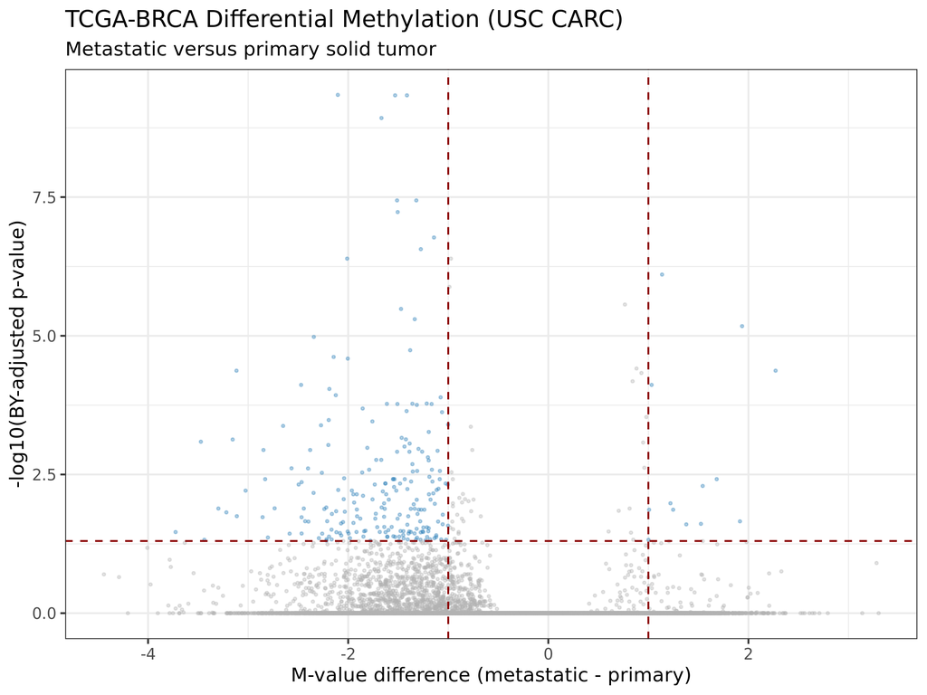

```r
knitr::include_graphics(
  file.path(figures_dir, "01_methylation_volcano_metastatic_vs_primary.png")
)
```

**Interpretation.** The CARC analysis identifies 225 CpG probes with BY-adjusted p < 0.05 and an absolute metastatic-minus-primary M-value difference of at least 1. Of these, 212 have negative differences and 13 have positive differences, so the significant results are dominated by lower methylation in the five metastatic specimens. The smaller positive set indicates focal hypermethylation that could be relevant to transcriptional repression. Because the comparison contains only five metastatic specimens and is highly imbalanced, these associations are exploratory rather than evidence of a population-wide causal effect.

# 2 2. Methylation status versus transcriptional activity

I used GDC integer STAR counts, retained genes with a total count of at least 20, and ran DESeq2 with the phenotype transferred from `methylation_clinical$definition`. Following the technical tips, candidate downregulated genes had DESeq2 adjusted p < 0.05 and RNA log2 fold change < -1, while candidate hypermethylated genes had at least one CpG with M-value difference > 1.5 as shown in the homework example. Their intersection contained one gene, `CD164L2`, which was therefore selected for the direct comparison.

```r
rna_counts <- rna_counts[rowSums(rna_counts) >= 20, , drop = FALSE]
dds <- DESeqDataSetFromMatrix(rna_counts, rna_clinical, ~ definition)
dds <- DESeq(dds)
de_results <- as.data.table(as.data.frame(results(
  dds, contrast = c("definition", "Metastatic", "Primary solid Tumor")
)), keep.rownames = "gene_id")

de_results[, gene_name := rna_gene_names[match(gene_id, rownames(rna_counts))]]

downregulated <- unique(de_results[
  !is.na(padj) & padj < 0.05 & log2FoldChange < -1, gene_name
])
hypermethylated <- unique(methylation_results[
  m_value_difference > 1.5, gene_name
])
interest_genes <- intersect(downregulated, hypermethylated)

candidate_rna <- de_results[gene_name %in% interest_genes]
setorder(candidate_rna, padj, -abs(log2FoldChange))
selected_gene <- candidate_rna$gene_name[1]
```

```r
de_file <- file.path(results_dir, "deseq2_results_metastatic_vs_primary.csv.gz")
de_results <- fread(cmd = paste("gzip -dc", shQuote(de_file)))
cd164l2_rna <- de_results[gene_name == "CD164L2",
  .(gene_name, baseMean, log2FoldChange, pvalue, padj)]
cd164l2_cpg <- methylation_results[
  gene_name == "CD164L2" & m_value_difference > 1.5,
  .(probe_id, gene_name, m_value_difference, p_value, adj_p_value)
]
knitr::kable(cd164l2_rna, digits = 4,
             caption = "CD164L2 differential expression")
```

CD164L2 differential expression

| gene_name | baseMean | log2FoldChange | pvalue | padj |
| --- | --- | --- | --- | --- |
| CD164L2 | 87.9029 | -3.0808 | 1e-04 | 0.0111 |

```r
knitr::kable(cd164l2_cpg, digits = 4,
             caption = "CD164L2 CpG passing the hypermethylation effect threshold")
```

CD164L2 CpG passing the hypermethylation effect threshold

| probe_id | gene_name | m_value_difference | p_value | adj_p_value |
| --- | --- | --- | --- | --- |
| cg11955474 | CD164L2 | 1.6433 | 0.0435 | 1 |

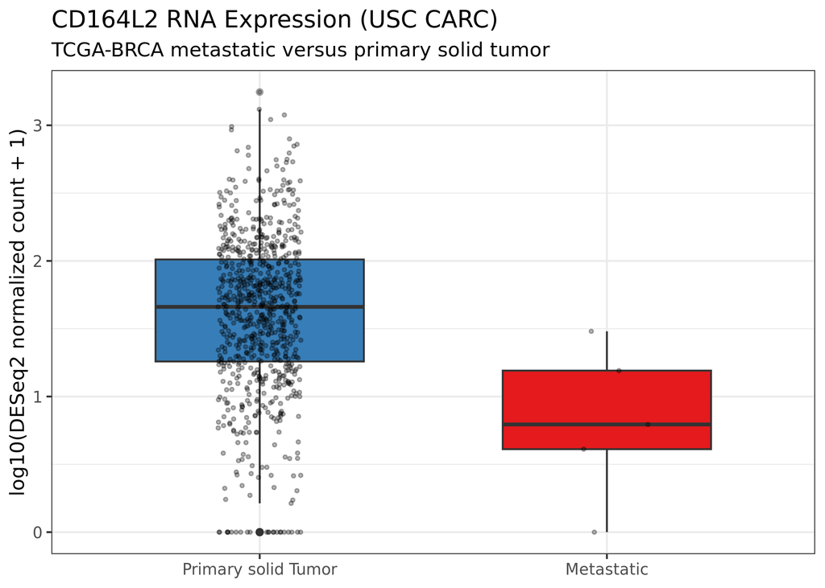

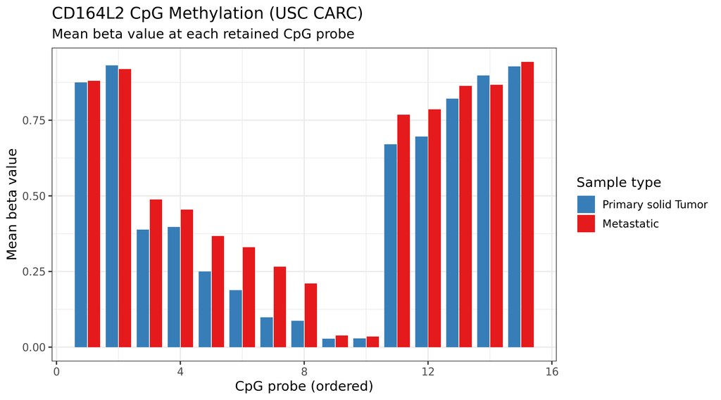

```r
knitr::include_graphics(c(
  file.path(figures_dir, "02_selected_gene_rna_expression_boxplot.png"),
  file.path(figures_dir, "03_selected_gene_cpg_methylation_barplot.png")
))
```

**Interpretation.** `CD164L2` expression is lower in metastatic tumors, with a DESeq2 log2 fold change of -3.081 and adjusted p = 0.01115; the expression boxplot shows the same direction despite the small metastatic group. The associated probe `cg11955474` has a metastatic-minus-primary M-value difference of 1.643, and the bar plot shows higher metastatic mean beta values at this and several other `CD164L2` CpGs. The CpG’s own BY-adjusted p-value is 1, so the integrated candidate is based on the assignment’s methylation effect-size threshold rather than CpG-level statistical significance. Together the assays suggest an exploratory inverse methylation-expression relationship, but they do not establish causality, especially with only five metastatic samples and possible tumor-composition or clinical confounding.

## 2.1 Reproducibility

```r
cat(readLines(file.path(results_dir, "sessionInfo_carc.txt")), sep = "\n")
```

[output not shown]